# Análise da Base de Dados Adult

# Sobre a base de dados

O conjunto de dados utilizado é chamado “Adult” e foi derivado do banco de dados do censo dos EUA. Foi preparado por Barry Becker a partir do censo de 1994. O propósito desse conjunto de dados é prever se uma pessoa ganha mais ou menos de US$ 50.000 por ano.

Link do conjunto de dados: https://archive.ics.uci.edu/ml/datasets/Adult

# Carregando os Dados do arquivo

```r
database <- read.csv(file = "Adult.CSV")

colnames(database) <- c("age", "workclass", "fnlwgt", "education", "education_num", "marital_status", "occupation", "relationship", "race", "sex", "capital_gain", "capital_loss", "hours_per_week", "native_country", "income")

#Printar a base de dados
database
```

Adult Database - Part 1

| age | workclass | fnlwgt | education | education_num | marital_status | occupation |
| --- | --- | --- | --- | --- | --- | --- |
| 39 | State-gov | 77516 | Bachelors | 13 | Never-married | Adm-clerical |
| 50 | Self-emp-not-inc | 83311 | Bachelors | 13 | Married-civ-spouse | Exec-managerial |
| 38 | Private | 215646 | HS-grad | 9 | Divorced | Handlers-cleaners |
| 53 | Private | 234721 | 11th | 7 | Married-civ-spouse | Handlers-cleaners |
| 28 | Private | 338409 | Bachelors | 13 | Married-civ-spouse | Prof-specialty |

Adult Database - Part 2

| relationship | race | sex | capital_gain | capital_loss | hours_per_week | native_country | income |
| --- | --- | --- | --- | --- | --- | --- | --- |
| Not-in-family | White | Male | 2174 | 0 | 40 | United-States | <=50K |
| Husband | White | Male | 0 | 0 | 13 | United-States | <=50K |
| Not-in-family | White | Male | 0 | 0 | 40 | United-States | <=50K |
| Husband | Black | Male | 0 | 0 | 40 | United-States | <=50K |
| Wife | Black | Female | 0 | 0 | 40 | Cuba | <=50K |

# 1. Identificação do atributo alvo (saída)

A base de dados possui 32561 exemplos e 15 atributos sendo seu atributo alvo “income”

```r
target_attribute <- "income"
```

# 2. Identificação dos tipos de dados dos atributos de entrada (quantitativo, qualitativo)

Identificar os tipos de dados em uma base de dados é essencial para entender a natureza das informações presentes. Na base de dados analisada, os dados podem ser classificados nas seguintes categorias:

- Categóricos: Representam características com valores qualitativos.
- Numéricos: Representam valores numéricos.

```r
#Para classificação dos atributos como int ou char
  str(database)
```

```
## 'data.frame':    32562 obs. of  15 variables:
##  $ age           : int  39 50 38 53 28 37 49 52 31 42 ...
##  $ workclass     : chr  " State-gov" " Self-emp-not-inc" " Private" " Private" ...
##  $ fnlwgt        : int  77516 83311 215646 234721 338409 284582 160187 209642 45781 159449 ...
##  $ education     : chr  " Bachelors" " Bachelors" " HS-grad" " 11th" ...
##  $ education_num : int  13 13 9 7 13 14 5 9 14 13 ...
##  $ marital_status: chr  " Never-married" " Married-civ-spouse" " Divorced" " Married-civ-spouse" ...
##  $ occupation    : chr  " Adm-clerical" " Exec-managerial" " Handlers-cleaners" " Handlers-cleaners" ...
##  $ relationship  : chr  " Not-in-family" " Husband" " Not-in-family" " Husband" ...
##  $ race          : chr  " White" " White" " White" " Black" ...
##  $ sex           : chr  " Male" " Male" " Male" " Male" ...
##  $ capital_gain  : int  2174 0 0 0 0 0 0 0 14084 5178 ...
##  $ capital_loss  : int  0 0 0 0 0 0 0 0 0 0 ...
##  $ hours_per_week: int  40 13 40 40 40 40 16 45 50 40 ...
##  $ native_country: chr  " United-States" " United-States" " United-States" " United-States" ...
##  $ income        : chr  " <=50K" " <=50K" " <=50K" " <=50K" ...
```

```r
#classificação manual
data_types <- c(
  age = "quantitativo",
  workclass = "qualitativo",
  fnlwgt = "quantitativo",
  education = "qualitativo",
  education_num = "quantitativo",
  marital_status = "qualitativo",
  occupation = "qualitativo",
  relationship = "qualitativo",
  race = "qualitativo",
  sex = "qualitativo",
  capital_gain = "quantitativo",
  capital_loss = "quantitativo",
  hours_per_week = "quantitativo",
  native_country = "qualitativo",
  income = "qualitativo"
)
data_types
```

Tipos de dados dos atributos de entrada

| Atributo | Classificação |
| --- | --- |
| age | quantitativo |
| workclass | qualitativo |
| fnlwgt | quantitativo |
| education | qualitativo |
| education_num | quantitativo |
| marital_status | qualitativo |
| occupation | qualitativo |
| relationship | qualitativo |
| race | qualitativo |
| sex | qualitativo |
| capital_gain | quantitativo |
| capital_loss | quantitativo |
| hours_per_week | quantitativo |
| native_country | qualitativo |
| income | qualitativo |

# 3. Identificação da escala de dados dos atributos de entrada (nominal, ordinal, intervalar, racional)

A identificação da escala de dados é relevante para entender a natureza e a magnitude dos valores presentes em uma base de dados. A escala dos dados pode ser dividida em quatro categorias principais:

- Nominal: Categorizados em diferentes grupos ou categorias, sem qualquer ordem ou hierarquia específica.
- Ordinal: Possuem uma ordem ou hierarquia específica, mas a diferença entre os valores não é necessariamente uniforme.
- Intervalar: Expressos em valores numéricos com uma diferença uniforme entre eles.
- Racional: Representam um valor numérico absoluto.

```r
data_scales <- c(
  age = "Racional",
  workclass = "Nominal",
  fnlwgt = "Racional",
  education = "Ordinal",
  education_num = "Ordinal",
  marital_status = "Nominal",
  occupation = "Nominal",
  relationship = "Nominal",
  race = "Nominal",
  sex = "Nominal",
  capital_gain = "Racional",
  capital_loss = "Racional",
  hours_per_week = "Racional",
  native_country = "Nominal",
  income = "Nominal"
)
data_scales
```

Identificação da escala de dados

| Atributo | Escala |
| --- | --- |
| age | Racional |
| workclass | Nominal |
| fnlwgt | Racional |
| education | Ordinal |
| education_num | Ordinal |
| marital_status | Nominal |
| occupation | Nominal |
| relationship | Nominal |
| race | Nominal |
| sex | Nominal |
| capital_gain | Racional |
| capital_loss | Racional |
| hours_per_week | Racional |
| native_country | Nominal |
| income | Nominal |

# 4. Exploração dos dados através de medidas de localidade

As medidas de localidade, fornecem informações sobre o valor central dos dados, no qual ajudam a entender onde a maioria dos dados está concentrado. Essas medidas ajudam a entender onde a maioria dos dados está concentrada. Incluem:

- Média
- Moda
- Mediana

```r
numeric_columns1 <- sapply(database, is.numeric)
summary(database[, numeric_columns1])
```

```
##       age            fnlwgt        education_num    capital_gain
##  Min.   :17.00   Min.   :  12285   Min.   : 1.00   Min.   :    0
##  1st Qu.:28.00   1st Qu.: 117827   1st Qu.: 9.00   1st Qu.:    0
##  Median :37.00   Median : 178356   Median :10.00   Median :    0
##  Mean   :38.58   Mean   : 189778   Mean   :10.08   Mean   : 1078
##  3rd Qu.:48.00   3rd Qu.: 237051   3rd Qu.:12.00   3rd Qu.:    0
##  Max.   :90.00   Max.   :1484705   Max.   :16.00   Max.   :99999
##  NA's   :1       NA's   :1         NA's   :1       NA's   :1
##   capital_loss    hours_per_week
##  Min.   :   0.0   Min.   : 1.00
##  1st Qu.:   0.0   1st Qu.:40.00
##  Median :   0.0   Median :40.00
##  Mean   :  87.3   Mean   :40.44
##  3rd Qu.:   0.0   3rd Qu.:45.00
##  Max.   :4356.0   Max.   :99.00
##  NA's   :1        NA's   :1
```

```r
Modes <- function(x) {
  ux <- unique(x)
  tab <- tabulate(match(x, ux))
  ux[tab == max(tab)]
}

for (i in 1:ncol(database)) {
  mod_val <- Modes(database[,i])
  print(mod_val)
}
```

```
## [1] 36
## [1] " Private"
## [1] 123011 164190 203488
## [1] " HS-grad"
## [1] 9
## [1] " Married-civ-spouse"
## [1] " Prof-specialty"
## [1] " Husband"
## [1] " White"
## [1] " Male"
## [1] 0
## [1] 0
## [1] 40
## [1] " United-States"
## [1] " <=50K"
```

# 5. Exploração dos dados através de medidas de espalhamento

As medidas de espalhamento são utilizadas para avaliar a dispersão ou variabilidade dos dados em um conjunto de observações. Elas fornecem informações sobre o quão distantes os valores estão uns dos outros e da medida central dos dados. Incluem

- Variância
- Desvio Padrão
- Amplitude

```r
spread_measures <- function(x) {
  c(variance = var(x, na.rm = TRUE), sd = sd(x, na.rm = TRUE), range = range(x, na.rm = TRUE))
}

# Identifica quais colunas são numéricas.
numeric_columns2 <- sapply(database, is.numeric)
# Aplica a função spread_measures a cada coluna numérica para calcular a variância, desvio padrão e amplitude para cada uma
sapply(database[, numeric_columns2], spread_measures)
```

```
##                age      fnlwgt education_num capital_gain capital_loss
## variance 186.06140 11140797792       6.61889 54542539.178  162376.9378
## sd        13.64043      105550       2.57272     7385.292     402.9602
## range1    17.00000       12285       1.00000        0.000       0.0000
## range2    90.00000     1484705      16.00000    99999.000    4356.0000
##          hours_per_week
## variance      152.45900
## sd             12.34743
## range1          1.00000
## range2         99.00000
```

# 6. Exploração dos dados através de medidas de distribuição

As medidas de distribuição são utilizadas para analisar a forma e a natureza da distribuição dos dados em um conjunto de observações.Essas medidas fornecem informações sobre a simetria, o achatamento e a forma geral da distribuição dos dados. Incluem:

- Assimetria
- Curtose

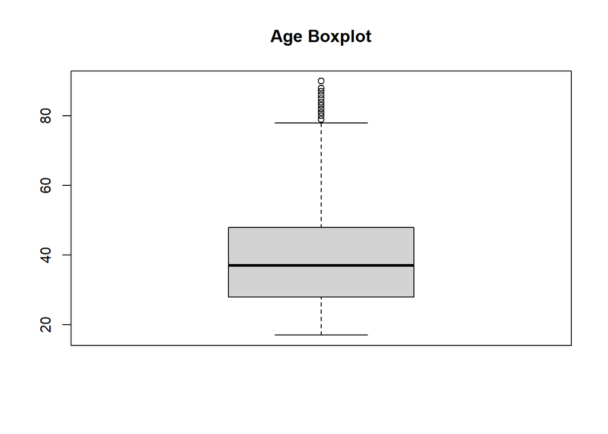

```r
# Funções para calcular assimetria e curtose
calc_skewness <- function(x) {
  n <- length(x)
  mean_x <- mean(x, na.rm = TRUE)
  sd_x <- sd(x, na.rm = TRUE)
  skewness <- sum(((x - mean_x) / sd_x) ^ 3, na.rm = TRUE) / n
  return(skewness)
}

calc_kurtosis <- function(x) {
  n <- length(x)
  mean_x <- mean(x, na.rm = TRUE)
  sd_x <- sd(x, na.rm = TRUE)
  kurtosis <- sum(((x - mean_x) / sd_x) ^ 4, na.rm = TRUE) / n - 3
  return(kurtosis)
}

numeric_columns3 <- sapply(database, is.numeric)

# Plotando boxplots para cada variável numérica
boxplot(database$age, main = "Age Boxplot")
```

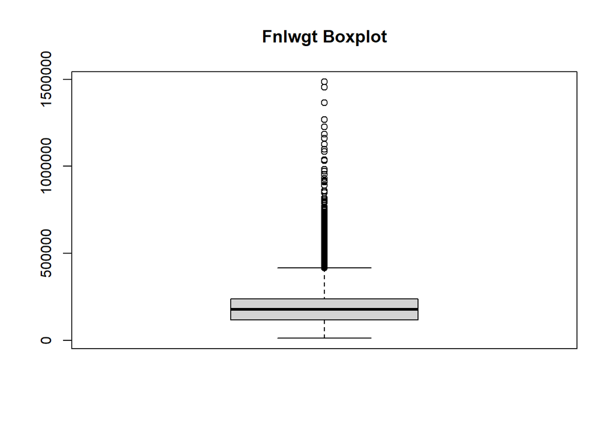

```r
boxplot(database$fnlwgt, main = "Fnlwgt Boxplot")
```

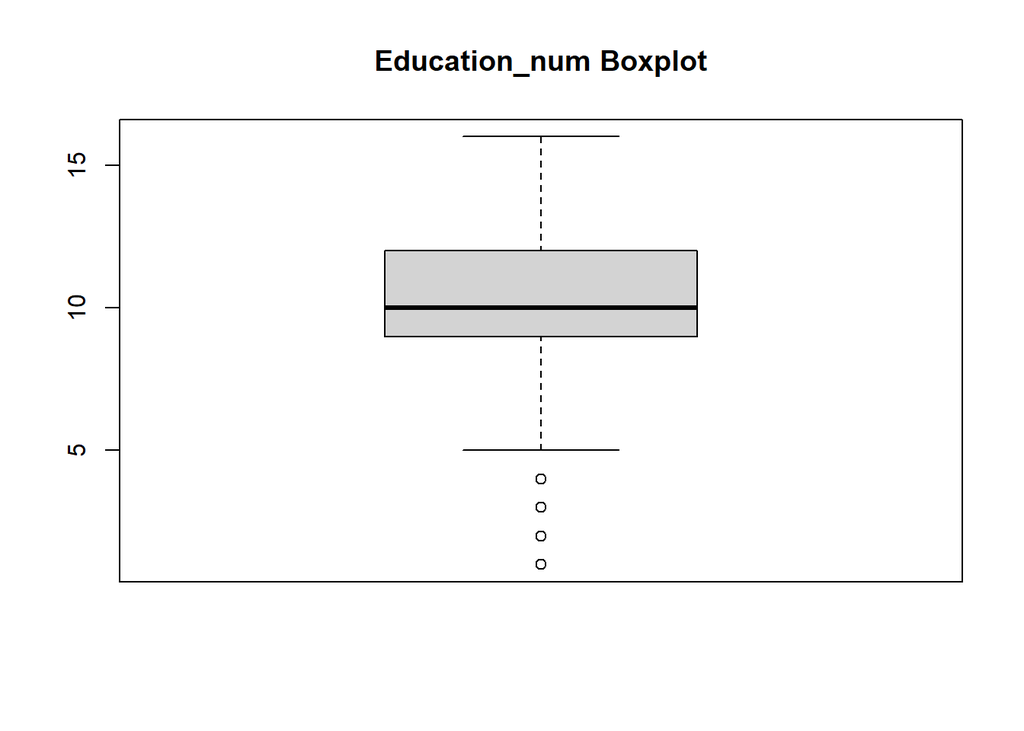

```r
boxplot(database$education_num, main = "Education_num Boxplot")
```

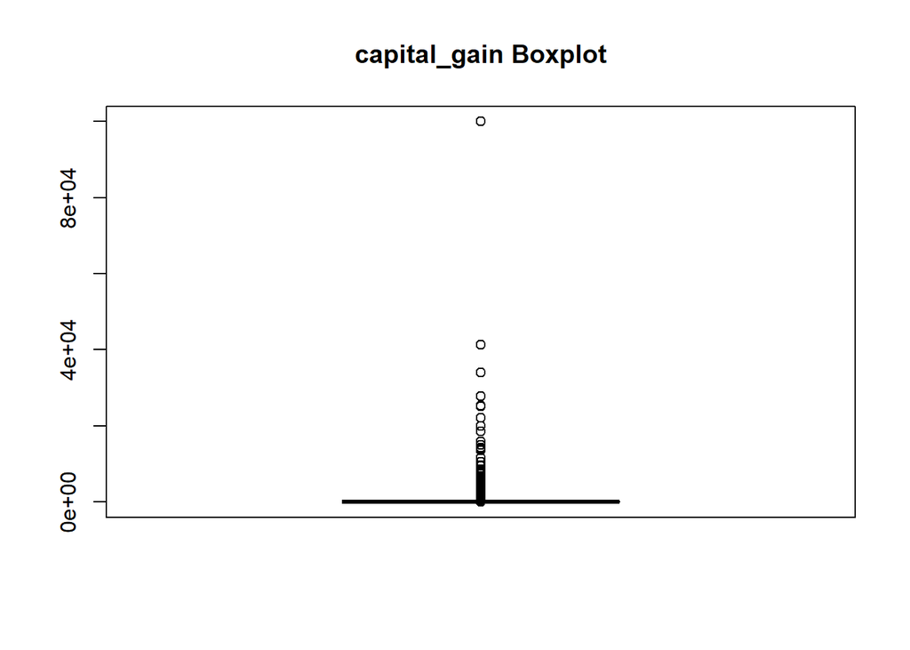

```r
boxplot(database$capital_gain, main = "capital_gain Boxplot")
```

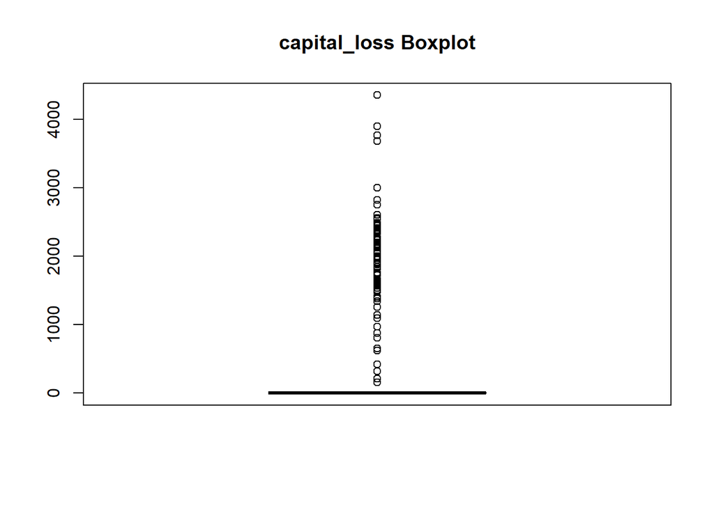

```r
boxplot(database$capital_loss, main = "capital_loss Boxplot")
```

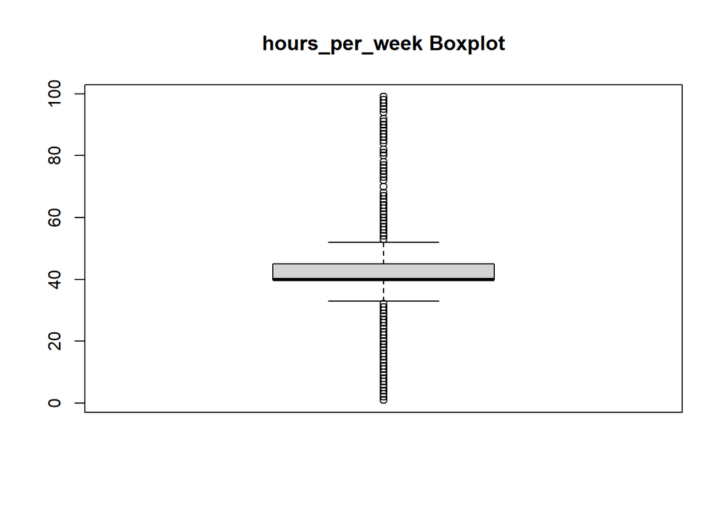

```r
boxplot(database$hours_per_week, main = "hours_per_week Boxplot")
```

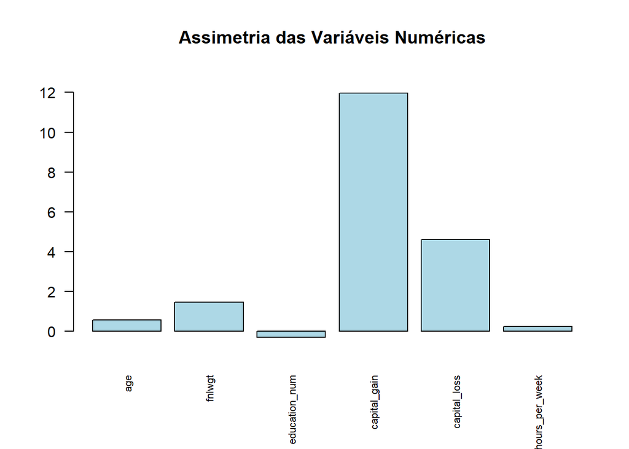

```r
# Calculando assimetria e curtose
skewness_values <- sapply(database[, numeric_columns3], calc_skewness)
kurtosis_values <- sapply(database[, numeric_columns3], calc_kurtosis)

# Criando um dataframe para plotagem
metrics_df <- data.frame(
  Variable = names(skewness_values),
  Skewness = skewness_values,
  Kurtosis = kurtosis_values
)

# Gráfico de assimetria
barplot(metrics_df$Skewness, names.arg = metrics_df$Variable,
        main = "Assimetria das Variáveis Numéricas",
        col = "lightblue", ylim = c(min(metrics_df$Skewness) - 1, max(metrics_df$Skewness) + 1),
        cex.names = 0.7, las = 2)
```

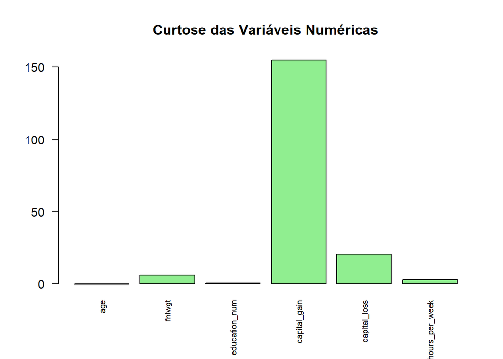

```r
# Gráfico de curtose
barplot(metrics_df$Kurtosis, names.arg = metrics_df$Variable,
        main = "Curtose das Variáveis Numéricas",
        col = "lightgreen", ylim = c(min(metrics_df$Kurtosis) - 1, max(metrics_df$Kurtosis) + 1),
        cex.names = 0.7, las = 2)
```

# 7. Identificação e separação do conjunto de teste

A base de dados original possui 32561 exemplos e 15 atributos

A base de dados teste possui 16281 exemplos e 15 atributos

O que implica em uma base de dados com metade dos exemplos.

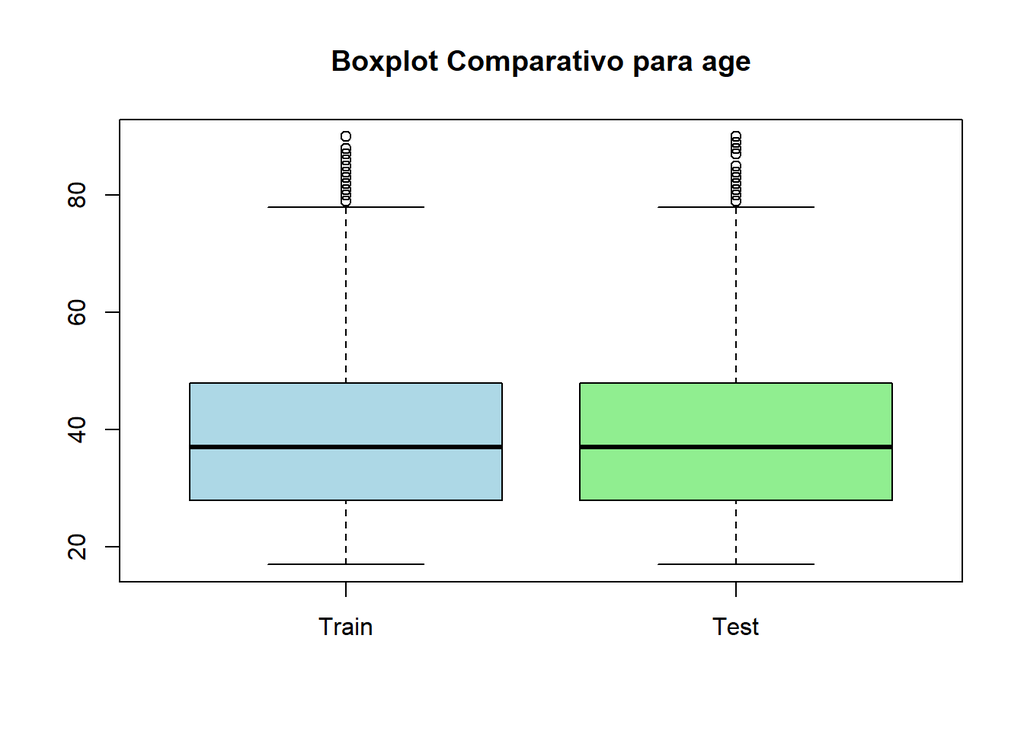

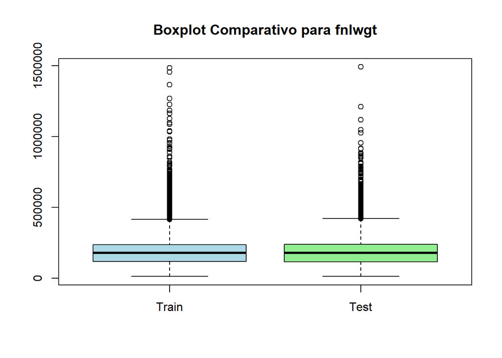

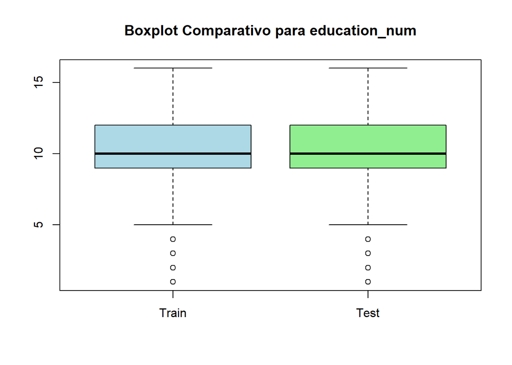

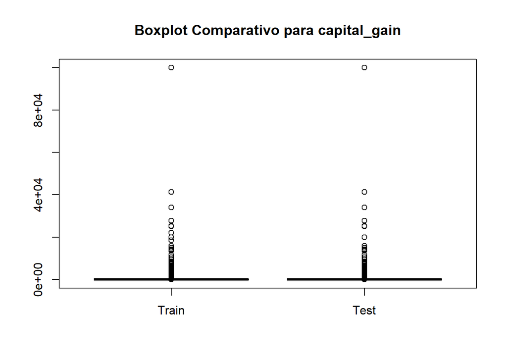

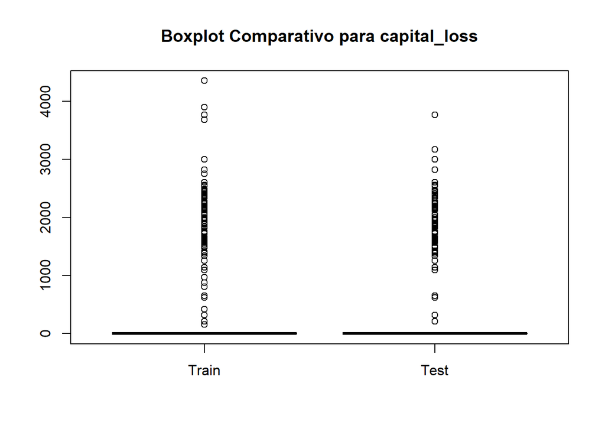

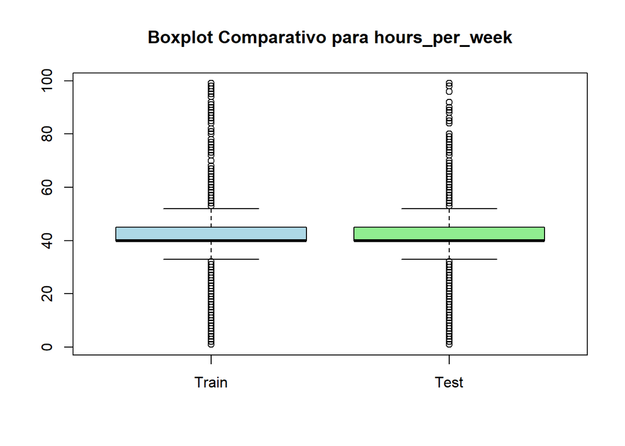

```r
train_data <- read.csv(file = "Adult.CSV")
test_data <- read.csv(file = "adultTest.csv")

colnames(train_data) <- c("age", "workclass", "fnlwgt", "education", "education_num", "marital_status", "occupation", "relationship", "race", "sex", "capital_gain", "capital_loss", "hours_per_week", "native_country", "income")

colnames(test_data) <- c("age", "workclass", "fnlwgt", "education", "education_num", "marital_status", "occupation", "relationship", "race", "sex", "capital_gain", "capital_loss", "hours_per_week", "native_country", "income")
test_data$income <- gsub(" >50K.", " >50K", test_data$income)
test_data$income <- gsub(" <=50K.", " <=50K", test_data$income)

# Identificando colunas numéricas
numeric_columns <- sapply(train_data, is.numeric)

par(mfrow=c(1, 1))
for (col in names(train_data)[numeric_columns]) {
  boxplot(train_data[[col]], test_data[[col]],
          names = c("Train", "Test"),
          main = paste("Boxplot Comparativo para", col),
          col = c("lightblue", "lightgreen"))
}
```

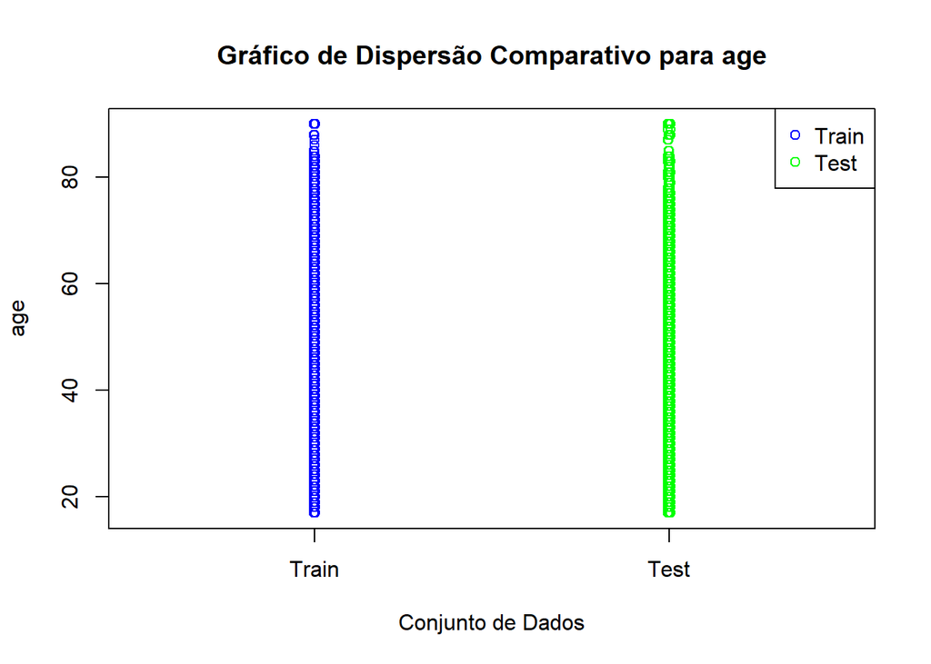

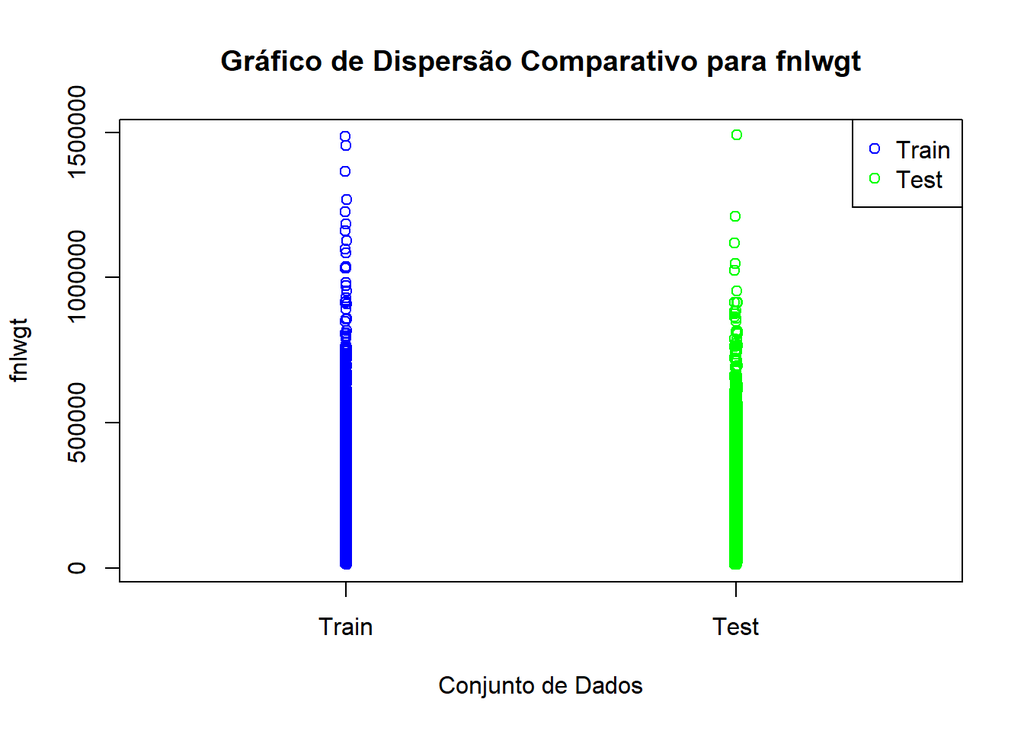

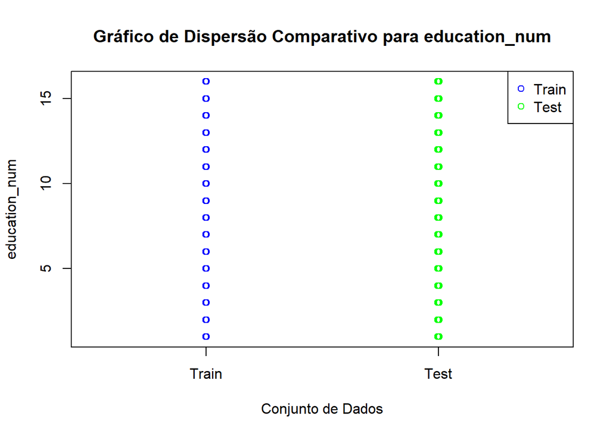

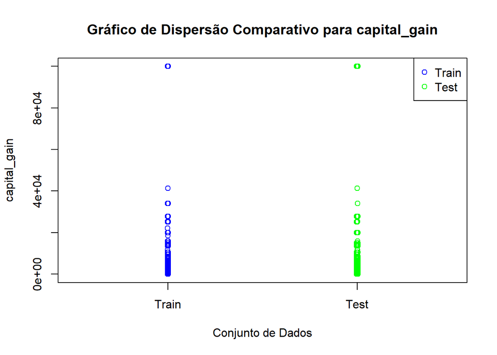

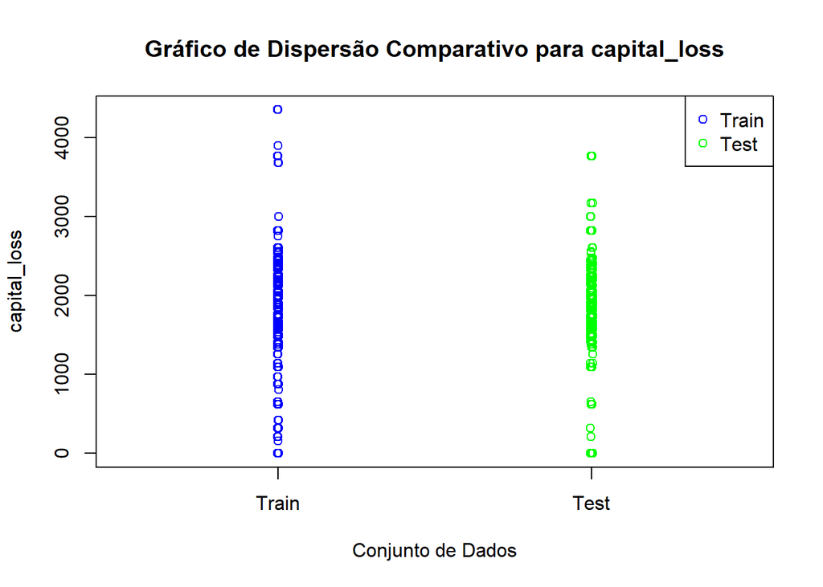

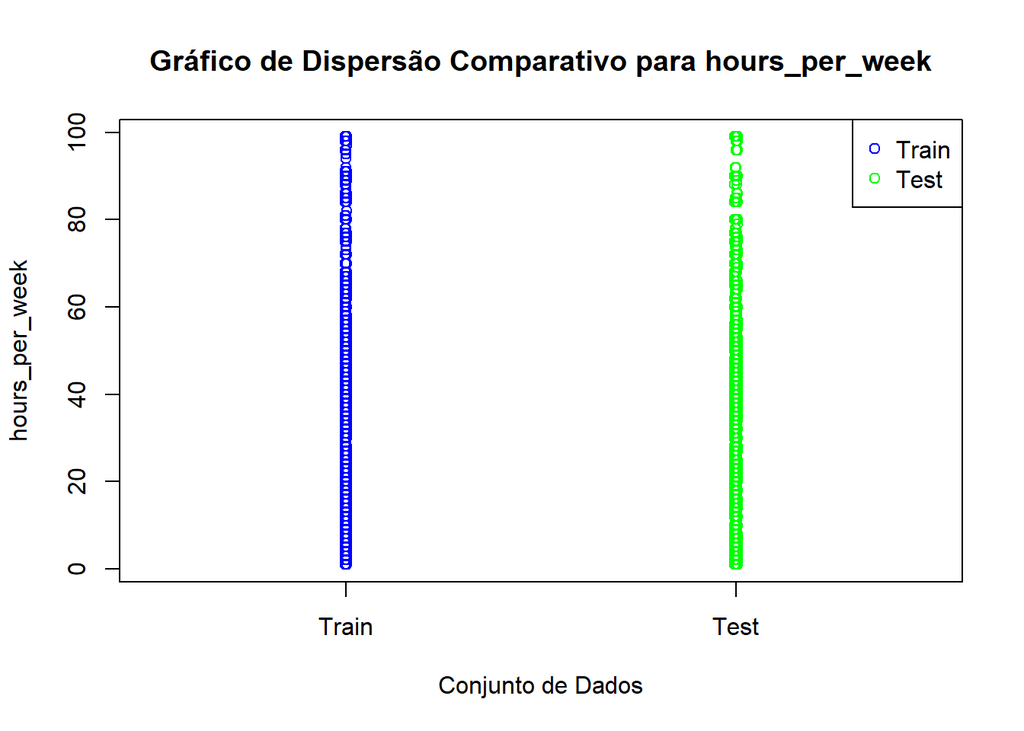

```r
jitter_horizontal <- function(x) {
  jitter(x, factor = 0.1)
}

# Criando um loop para gerar gráficos de dispersão comparativos
for (col in names(train_data)[numeric_columns]) {
  plot(jitter_horizontal(rep(1, length(train_data[[col]]))), train_data[[col]],
       xlim = c(0.5, 2.5), xaxt = "n",
       main = paste("Gráfico de Dispersão Comparativo para", col),
       xlab = "Conjunto de Dados", ylab = col, col = "blue")

  points(jitter_horizontal(rep(2, length(test_data[[col]]))), test_data[[col]], col = "green")

  axis(1, at = 1:2, labels = c("Train", "Test"))
  legend("topright", legend = c("Train", "Test"), col = c("blue", "green"), pch = 1)
}
```

##### Os boxplots mostram a distribuição dos dados por meio de quartis, mediana, outliers e intervalo interquartil. Ao comparar os boxplots, nota-se que as medidas estatísticas, como quartis e mediana, são próximas entre as bases original e de teste. Isso sugere que os atributos estão sendo preservados de forma consistente na base de teste, com valores semelhantes aos do conjunto original. Os gráficos de dispersão mostram a relação entre dois atributos, permitindo observar a dispersão dos pontos. Ao comparar os gráficos de dispersão, podemos identificar se a relação entre os atributos é preservada na base de teste. Se os pontos seguem uma tendência semelhante e mantêm uma relação coerente, isso indica que a base de teste reflete adequadamente as características do conjunto original.

**Conclui-se que a base de dados de testes mantém as mesmas características da base de dados original.**

# 8. Identificação e eliminação de atributos não necessários

```r
#é a copia de education_num
train_data$education <- remove()
#Não é um dado significante para a base de dados
train_data$fnlwgt <- remove()
#Relationship é um subgrupo de marital_status
train_data$relationship <- remove()

test_data$education <- remove()
test_data$fnlwgt <- remove()
test_data$relationship <- remove()
```

# 9. Identificação e eliminação de exemplos não necessários

A única eliminação feita foi em uma linha na base de dados onde todos os atributos se encontram como “N/A”

```r
#Achar o único exemplo onde não há nada nele
empty_rows <- !complete.cases(train_data)
#Printar a linha no qual ele se encontra
print(train_data[empty_rows, ])
```

```
##       age workclass education_num marital_status occupation race sex
## 32562  NA                      NA
##       capital_gain capital_loss hours_per_week native_country income
## 32562           NA           NA             NA
```

```r
#Remover a linha N/A
train_data <- train_data[-32562, ]

#Checando se há algum exemplo que está como NA na base de teste
empty_rows <- !complete.cases(test_data)
print(test_data[empty_rows, ])
```

```
##  [1] age            workclass      education_num  marital_status occupation
##  [6] race           sex            capital_gain   capital_loss   hours_per_week
## [11] native_country income
## <0 linhas> (ou row.names de comprimento 0)
```

# 10 e 11. Análise e aplicação de técnicas de amostragem de dados e desbalanceamento

Para realziar uma análise ou aplicar técnicas de amostragem de dados primeiro é preciso verificar se a base de dados de treinamento e teste estão desbalanceados.

```r
# Checar a distribuição da base de treinamento do atributo alvo
table(train_data$income)
```

```
##
##  <=50K   >50K
##  24720   7841
```

```r
# Calcular proporções
prop.table(table(train_data$income))
```

```
##
##     <=50K      >50K
## 0.7591904 0.2408096
```

```r
#Checar a distribuição da base de teste do atributo alvo
table(test_data$income)
```

```
##
##  <=50K   >50K
##  12434   3846
```

```r
prop.table(table(test_data$income))
```

```
##
##     <=50K      >50K
## 0.7637592 0.2362408
```

Como podemos ver ambas as bases estão desbalanceadas, e por isso vamos aplicar técnicas de amostragem de dados e desbalanceamento, a técnica de amostragem utilizada foi amostragem aleatória simples (Sem reposição de exemplos) e para técnicas de desbalanceamento foi utilizado a técnica de undersampling (Onde igualamos os números de casos da classe majoritária com o número de casos da classe minoritária).

```r
# Função para realizar amostragem estratificada
amostra_estratificada <- function(data, target_col) {
  # Separar as classes
  class_min <- subset(data, data[[target_col]] == " >50K")
  class_maj <- subset(data, data[[target_col]] == " <=50K")

  # Número de exemplos na classe minoritária
  num_min <- nrow(class_min)

  # Amostragem aleatória da classe majoritária
  set.seed(123) # para reprodutibilidade
  class_maj_sampled <- class_maj[sample(nrow(class_maj), num_min, replace = FALSE), ]

  # Combinar as classes amostradas
  balanced_data <- rbind(class_min, class_maj_sampled)

  # Embaralhar os dados para evitar ordenação por classe
  balanced_data <- balanced_data[sample(nrow(balanced_data)), ]

  return(balanced_data)
}

# Aplicar a função nas bases de dados
train_data_balanced <- amostra_estratificada(train_data, "income")
test_data_balanced <- amostra_estratificada(test_data, "income")

# Nova distribuição da base de treinamento
table(train_data_balanced$income)
```

```
##
##  <=50K   >50K
##   7841   7841
```

```r
prop.table(table(train_data_balanced$income))
```

```
##
##  <=50K   >50K
##    0.5    0.5
```

```r
# Nova distribuição da base de teste
table(test_data_balanced$income)
```

```
##
##  <=50K   >50K
##   3846   3846
```

```r
prop.table(table(test_data_balanced$income))
```

```
##
##  <=50K   >50K
##    0.5    0.5
```

# 12. Limpeza de Dados

Para a limpeza de dados, foram realizadas as seguintes etapas:

## 1. Tratamento de valores ausentes: Foram substituídos os valores ausentes pela moda de cada coluna.

Nesse caso foi optado por substituir os valores ausentes pela moda de cada coluna, pois a moda é uma medida de tendência central que representa o valor mais frequente em um conjunto de dados. Substituir os valores ausentes pela moda ajuda a manter a consistência dos dados e a preservar a distribuição original.

```r
# Substituir " ?" por NA
train_data[train_data == " ?"] <- NA
test_data[test_data == " ?"] <- NA

# Imprimir a porcentagem de valores NA em cada coluna para verificar
print(sapply(train_data, function(col) {
  sum(is.na(col)) * 100 / length(col)
}))
```

```
##            age      workclass  education_num marital_status     occupation
##       0.000000       5.638647       0.000000       0.000000       5.660146
##           race            sex   capital_gain   capital_loss hours_per_week
##       0.000000       0.000000       0.000000       0.000000       0.000000
## native_country         income
##       1.790486       0.000000
```

```r
print(sapply(test_data, function(col) {
  sum(is.na(col)) * 100 / length(col)
}))
```

```
##            age      workclass  education_num marital_status     occupation
##       0.000000       5.915233       0.000000       0.000000       5.933661
##           race            sex   capital_gain   capital_loss hours_per_week
##       0.000000       0.000000       0.000000       0.000000       0.000000
## native_country         income
##       1.683047       0.000000
```

```r
# Função para calcular a moda
Modes <- function(x) {
  ux <- unique(x)
  ux[which.max(tabulate(match(x, ux)))]
}

# Substituir NA pela moda em cada coluna do train_data
train_data <- data.frame(lapply(train_data, function(col) {
  if (any(is.na(col))) {
    col[is.na(col)] <- Modes(col[!is.na(col)])
  }
  return(col)
}))

# Substituir NA pela moda em cada coluna do test_data
test_data <- data.frame(lapply(test_data, function(col) {
  if (any(is.na(col))) {
    col[is.na(col)] <- Modes(col[!is.na(col)])
  }
  return(col)
}))

# Imprimir a porcentagem de valores NA em cada coluna para verificar
print(sapply(train_data, function(col) {
  sum(is.na(col)) * 100 / length(col)
}))
```

```
##            age      workclass  education_num marital_status     occupation
##              0              0              0              0              0
##           race            sex   capital_gain   capital_loss hours_per_week
##              0              0              0              0              0
## native_country         income
##              0              0
```

```r
print(sapply(test_data, function(col) {
  sum(is.na(col)) * 100 / length(col)
}))
```

```
##            age      workclass  education_num marital_status     occupation
##              0              0              0              0              0
##           race            sex   capital_gain   capital_loss hours_per_week
##              0              0              0              0              0
## native_country         income
##              0              0
```

## 2. Remoção de duplicatas: Foram removidas as linhas duplicadas da base de dados.

A remoção de duplicatas é importante para garantir a integridade dos dados e evitar viés na análise. A presença de linhas duplicadas pode distorcer os resultados e levar a conclusões errôneas. Portanto, é essencial remover duplicatas para manter a qualidade dos dados.

```r
# Verificar duplicatas no train_data
duplicated_train <- duplicated(train_data)
any_duplicated_train <- any(duplicated_train)
print(paste("Existem linhas duplicadas em train_data:", any_duplicated_train))
```

```
## [1] "Existem linhas duplicadas em train_data: TRUE"
```

```r
# Verificar duplicatas no test_data
duplicated_test <- duplicated(test_data)
any_duplicated_test <- any(duplicated_test)
print(paste("Existem linhas duplicadas em test_data:", any_duplicated_test))
```

```
## [1] "Existem linhas duplicadas em test_data: TRUE"
```

```r
# Remover linhas duplicadas do train_data
train_data <- train_data[!duplicated(train_data), ]

# Remover linhas duplicadas do test_data
test_data <- test_data[!duplicated(test_data), ]

# Verificar novamente duplicatas no train_data
duplicated_train <- duplicated(train_data)
any_duplicated_train <- any(duplicated_train)
print(paste("Existem linhas duplicadas em train_data:", any_duplicated_train))
```

```
## [1] "Existem linhas duplicadas em train_data: FALSE"
```

```r
# Verificar novamente duplicatas no test_data
duplicated_test <- duplicated(test_data)
any_duplicated_test <- any(duplicated_test)
print(paste("Existem linhas duplicadas em test_data:", any_duplicated_test))
```

```
## [1] "Existem linhas duplicadas em test_data: FALSE"
```

## 3. Criação de grupos para valores categóricos: Foram agrupados os valores categóricos em grupos mais amplos para simplificar a análise.

A criação de grupos para valores categóricos é útil para reduzir a complexidade dos dados e facilitar a análise. Agrupar valores categóricos semelhantes em categorias mais amplas pode ajudar a identificar padrões e tendências nos dados. Além disso, a criação de grupos pode melhorar a interpretação dos resultados e simplificar a visualização dos dados.

```r
#Criação de grupos para alocar grupos parecidos (WorkClass)
train_data$workclass <- as.character(train_data$workclass)

train_data$workclass[train_data$workclass == " Without-pay" |
                   train_data$workclass == " Never-worked"] <- " Unemployed"

train_data$workclass[train_data$workclass == " State-gov" |
                  train_data$workclass == " Local-gov"] <- " SL-gov"

train_data$workclass[train_data$workclass == " Self-emp-inc" |
                  train_data$workclass == " Self-emp-not-inc"] <- " Self-employed"

table(train_data$workclass)
```

```
##
##    Federal-gov        Private  Self-employed         SL-gov     Unemployed
##            939          20256           3558           3276             21
```

```r
test_data$workclass <- as.character(test_data$workclass)

test_data$workclass[test_data$workclass == " Without-pay" |
                   test_data$workclass == " Never-worked"] <- " Unemployed"

test_data$workclass[test_data$workclass == " State-gov" |
                  test_data$workclass == " Local-gov"] <- " SL-gov"

test_data$workclass[test_data$workclass == " Self-emp-inc" |
                  test_data$workclass == " Self-emp-not-inc"] <- " Self-employed"

table(test_data$workclass)
```

```
##
##    Federal-gov        Private  Self-employed         SL-gov     Unemployed
##            469          10802           1874           1702             10
```

```r
#Criação de grupos para alocar grupos parecidos (Marital Status)
table(train_data$marital_status)
```

```
##
##               Divorced      Married-AF-spouse     Married-civ-spouse
##                   4067                     23                  13171
##  Married-spouse-absent          Never-married              Separated
##                    418                   8393                   1002
##                Widowed
##                    976
```

```r
train_data$marital_status <- as.character(train_data$marital_status)

train_data$marital_status[train_data$marital_status == " Married-AF-spouse" |
                       train_data$marital_status == " Married-civ-spouse" |
                       train_data$marital_status == " Married-spouse-absent"] <- " Married"

train_data$marital_status[train_data$marital_status == " Divorced" |
                       train_data$marital_status == " Separated" |
                       train_data$marital_status == " Widowed"] <- " Not-Married"
table(train_data$marital_status)
```

```
##
##        Married  Never-married    Not-Married
##          13612           8393           6045
```

```r
table(test_data$marital_status)
```

```
##
##               Divorced      Married-AF-spouse     Married-civ-spouse
##                   2073                     14                   6875
##  Married-spouse-absent          Never-married              Separated
##                    210                   4663                    498
##                Widowed
##                    524
```

```r
test_data$marital_status <- as.character(test_data$marital_status)

test_data$marital_status[test_data$marital_status == " Married-AF-spouse" |
                       test_data$marital_status == " Married-civ-spouse" |
                       test_data$marital_status == " Married-spouse-absent"] <- " Married"

test_data$marital_status[test_data$marital_status == " Divorced" |
                       test_data$marital_status == " Separated" |
                       test_data$marital_status == " Widowed"] <- " Not-Married"
table(test_data$marital_status)
```

```
##
##        Married  Never-married    Not-Married
##           7099           4663           3095
```

```r
#Criação de grupos para alocar grupos parecidos (Native Country)
train_data$native_country <- as.character(train_data$native_country)

north_america <- c(" Canada", " Cuba", " Dominican-Republic", " El-Salvador", " Guatemala",
                   " Haiti", " Honduras", " Jamaica", " Mexico", " Nicaragua",
                   " Outlying-US(Guam-USVI-etc)", " Puerto-Rico", " Trinadad&Tobago",
                   " United-States")
asia <- c(" Cambodia", " China", " Hong", " India", " Iran", " Japan", " Laos",
          " Philippines", " Taiwan", " Thailand", " Vietnam")
south_america <- c(" Columbia", " Ecuador", " Peru")
europe <- c(" England", " France", " Germany", " Greece", " Holand-Netherlands",
            " Hungary", " Ireland", " Italy", " Poland", " Portugal", " Scotland",
            " Yugoslavia")
other <- c(" South")
train_data$native_country[train_data$native_country %in% north_america] <- " North America"
train_data$native_country[train_data$native_country %in% asia] <- " Asia"
train_data$native_country[train_data$native_country %in% south_america] <- " South America"
train_data$native_country[train_data$native_country %in% europe] <- " Europe"
train_data$native_country[train_data$native_country %in% other] <- " Other"

table(train_data$native_country)
```

```
##
##           Asia         Europe  North America          Other  South America
##            669            519          26664             80            118
```

```r
test_data$native_country <- as.character(test_data$native_country)

north_america <- c(" Canada", " Cuba", " Dominican-Republic", " El-Salvador", " Guatemala",
                   " Haiti", " Honduras", " Jamaica", " Mexico", " Nicaragua",
                   " Outlying-US(Guam-USVI-etc)", " Puerto-Rico", " Trinadad&Tobago",
                   " United-States")
asia <- c(" Cambodia", " China", " Hong", " India", " Iran", " Japan", " Laos",
          " Philippines", " Taiwan", " Thailand", " Vietnam")
south_america <- c(" Columbia", " Ecuador", " Peru")
europe <- c(" England", " France", " Germany", " Greece", " Holand-Netherlands",
            " Hungary", " Ireland", " Italy", " Poland", " Portugal", " Scotland",
            " Yugoslavia")
other <- c(" South")
test_data$native_country[test_data$native_country %in% north_america] <- " North America"
test_data$native_country[test_data$native_country %in% asia] <- " Asia"
test_data$native_country[test_data$native_country %in% south_america] <- " South America"
test_data$native_country[test_data$native_country %in% europe] <- " Europe"
test_data$native_country[test_data$native_country %in% other] <- " Other"

table(test_data$native_country)
```

```
##
##           Asia         Europe  North America          Other  South America
##            310            259          14195             35             58
```

## Tabela de Dados (Treinamento) após a limpeza

Adult Database - Train Data - Part 1

| age | workclass | education_num | marital_status | occupation |
| --- | --- | --- | --- | --- |
| 39 | SL-gov | 13 | Never-married | Adm-clerical |
| 50 | Self-employed | 13 | Married | Exec-managerial |
| 38 | Private | 9 | Not-Married | Handlers-cleaners |
| 53 | Private | 7 | Married | Handlers-cleaners |
| 28 | Private | 13 | Married | Prof-specialty |

Adult Database - Train Data - Part 2

| race | sex | capital_gain | capital_loss | hours_per_week | native_country | income |
| --- | --- | --- | --- | --- | --- | --- |
| White | Male | 2174 | 0 | 40 | North America | <=50K |
| White | Male | 0 | 0 | 13 | North America | <=50K |
| White | Male | 0 | 0 | 40 | North America | <=50K |
| Black | Male | 0 | 0 | 40 | North America | <=50K |
| Black | Female | 0 | 0 | 40 | North America | <=50K |

## Tabela de Dados (Teste) após a limpeza

Adult Database - Test Data - Part 1

| age | workclass | education_num | marital_status | occupation |
| --- | --- | --- | --- | --- |
| 38 | Private | 9 | Married | Farming-fishing |
| 28 | SL-gov | 12 | Married | Protective-serv |
| 44 | Private | 10 | Married | Machine-op-inspct |
| 18 | Private | 10 | Never-married | Prof-specialty |
| 34 | Private | 6 | Never-married | Other-service |

Adult Database - Test Data - Part 2

| race | sex | capital_gain | capital_loss | hours_per_week | native_country | income |
| --- | --- | --- | --- | --- | --- | --- |
| White | Male | 0 | 0 | 50 | North America | <=50K |
| White | Male | 0 | 0 | 40 | North America | >50K |
| Black | Male | 7688 | 0 | 40 | North America | >50K |
| White | Female | 0 | 0 | 30 | North America | <=50K |
| White | Male | 0 | 0 | 30 | North America | <=50K |

# 13. Identificação e conversão dos tipos de dados

Para a identificação e conversão dos tipos de dados, foram realizadas a conversão de tipo de dados simbólicos para numéricos, a fim de facilitar a análise e a modelagem dos dados.

```r
# Conversão dos valores de 'workclass' e 'marital_status'
table(train_data$workclass)
```

```
##
##    Federal-gov        Private  Self-employed         SL-gov     Unemployed
##            939          20256           3558           3276             21
```

```r
train_data$workclass <- ifelse(train_data$workclass == " Federal-gov", 0, train_data$workclass)
train_data$workclass <- ifelse(train_data$workclass == " Private", 1, train_data$workclass)
train_data$workclass <- ifelse(train_data$workclass == " Self-employed", 2, train_data$workclass)
train_data$workclass <- ifelse(train_data$workclass == " SL-gov", 3, train_data$workclass)
train_data$workclass <- ifelse(train_data$workclass == " Unemployed", 4, train_data$workclass)

table(test_data$workclass)
```

```
##
##    Federal-gov        Private  Self-employed         SL-gov     Unemployed
##            469          10802           1874           1702             10
```

```r
test_data$workclass <- ifelse(test_data$workclass == " Federal-gov", 0, test_data$workclass)
test_data$workclass <- ifelse(test_data$workclass == " Private", 1, test_data$workclass)
test_data$workclass <- ifelse(test_data$workclass == " Self-employed", 2, test_data$workclass)
test_data$workclass <- ifelse(test_data$workclass == " SL-gov", 3, test_data$workclass)
test_data$workclass <- ifelse(test_data$workclass == " Unemployed", 4, test_data$workclass)

table(train_data$marital_status)
```

```
##
##        Married  Never-married    Not-Married
##          13612           8393           6045
```

```r
train_data$marital_status <- ifelse(train_data$marital_status == " Married", 0, train_data$marital_status)
train_data$marital_status <- ifelse(train_data$marital_status == " Not-Married", 1, train_data$marital_status)
train_data$marital_status <- ifelse(train_data$marital_status == " Never-married", 2, train_data$marital_status)

table(test_data$marital_status)
```

```
##
##        Married  Never-married    Not-Married
##           7099           4663           3095
```

```r
test_data$marital_status <- ifelse(test_data$marital_status == " Married", 0, test_data$marital_status)
test_data$marital_status <- ifelse(test_data$marital_status == " Not-Married", 1, test_data$marital_status)
test_data$marital_status <- ifelse(test_data$marital_status == " Never-married", 2, test_data$marital_status)

# Conversão dos valores 'occupation'
table(train_data$occupation)
```

```
##
##       Adm-clerical       Armed-Forces       Craft-repair    Exec-managerial
##               3123                  9               3184               3652
##    Farming-fishing  Handlers-cleaners  Machine-op-inspct      Other-service
##                955               1121               1639               2832
##    Priv-house-serv     Prof-specialty    Protective-serv              Sales
##                146               5323                628               3150
##       Tech-support   Transport-moving
##                858               1430
```

```r
train_data$occupation <- ifelse(train_data$occupation == " Adm-clerical", 0, train_data$occupation)
train_data$occupation <- ifelse(train_data$occupation == " Armed-Forces", 1, train_data$occupation)
train_data$occupation <- ifelse(train_data$occupation == " Craft-repair", 2, train_data$occupation)
train_data$occupation <- ifelse(train_data$occupation == " Exec-managerial", 3, train_data$occupation)
train_data$occupation <- ifelse(train_data$occupation == " Farming-fishing", 4, train_data$occupation)
train_data$occupation <- ifelse(train_data$occupation == " Handlers-cleaners", 5, train_data$occupation)
train_data$occupation <- ifelse(train_data$occupation == " Machine-op-inspct", 6, train_data$occupation)
train_data$occupation <- ifelse(train_data$occupation == " Other-service", 7, train_data$occupation)
train_data$occupation <- ifelse(train_data$occupation == " Priv-house-serv", 8, train_data$occupation)
train_data$occupation <- ifelse(train_data$occupation == " Prof-specialty", 9, train_data$occupation)
train_data$occupation <- ifelse(train_data$occupation == " Protective-serv", 10, train_data$occupation)
train_data$occupation <- ifelse(train_data$occupation == " Sales", 11, train_data$occupation)
train_data$occupation <- ifelse(train_data$occupation == " Tech-support", 12, train_data$occupation)
train_data$occupation <- ifelse(train_data$occupation == " Transport-moving", 13, train_data$occupation)

table(test_data$occupation)
```

```
##
##       Adm-clerical       Armed-Forces       Craft-repair    Exec-managerial
##               1651                  6               1703               1899
##    Farming-fishing  Handlers-cleaners  Machine-op-inspct      Other-service
##                487                632                894               1488
##    Priv-house-serv     Prof-specialty    Protective-serv              Sales
##                 93               2754                328               1705
##       Tech-support   Transport-moving
##                502                715
```

```r
test_data$occupation <- ifelse(test_data$occupation == " Adm-clerical", 0, test_data$occupation)
test_data$occupation <- ifelse(test_data$occupation == " Armed-Forces", 1, test_data$occupation)
test_data$occupation <- ifelse(test_data$occupation == " Craft-repair", 2, test_data$occupation)
test_data$occupation <- ifelse(test_data$occupation == " Exec-managerial", 3, test_data$occupation)
test_data$occupation <- ifelse(test_data$occupation == " Farming-fishing", 4, test_data$occupation)
test_data$occupation <- ifelse(test_data$occupation == " Handlers-cleaners", 5, test_data$occupation)
test_data$occupation <- ifelse(test_data$occupation == " Machine-op-inspct", 6, test_data$occupation)
test_data$occupation <- ifelse(test_data$occupation == " Other-service", 7, test_data$occupation)
test_data$occupation <- ifelse(test_data$occupation == " Priv-house-serv", 8, test_data$occupation)
test_data$occupation <- ifelse(test_data$occupation == " Prof-specialty", 9, test_data$occupation)
test_data$occupation <- ifelse(test_data$occupation == " Protective-serv", 10, test_data$occupation)
test_data$occupation <- ifelse(test_data$occupation == " Sales", 11, test_data$occupation)
test_data$occupation <- ifelse(test_data$occupation == " Tech-support", 12, test_data$occupation)
test_data$occupation <- ifelse(test_data$occupation == " Transport-moving", 13, test_data$occupation)

# Conversão dos valores 'race'
table(train_data$race)
```

```
##
##  Amer-Indian-Eskimo  Asian-Pac-Islander               Black               Other
##                 311                1036                2972                 271
##               White
##               23460
```

```r
train_data$race <- ifelse(train_data$race == " Amer-Indian-Eskimo", 0, train_data$race)
train_data$race <- ifelse(train_data$race == " Asian-Pac-Islander", 1, train_data$race)
train_data$race <- ifelse(train_data$race == " Black", 2, train_data$race)
train_data$race <- ifelse(train_data$race == " Other", 3, train_data$race)
train_data$race <- ifelse(train_data$race == " White", 4, train_data$race)

table(test_data$race)
```

```
##
##  Amer-Indian-Eskimo  Asian-Pac-Islander               Black               Other
##                 159                 480                1521                 135
##               White
##               12562
```

```r
test_data$race <- ifelse(test_data$race == " Amer-Indian-Eskimo", 0, test_data$race)
test_data$race <- ifelse(test_data$race == " Asian-Pac-Islander", 1, test_data$race)
test_data$race <- ifelse(test_data$race == " Black", 2, test_data$race)
test_data$race <- ifelse(test_data$race == " Other", 3, test_data$race)
test_data$race <- ifelse(test_data$race == " White", 4, test_data$race)

# Conversão dos valores 'sex'
table(train_data$sex)
```

```
##
##  Female    Male
##    9314   18736
```

```r
train_data$sex <- ifelse(train_data$sex == " Male", 0, train_data$sex)
train_data$sex <- ifelse(train_data$sex == " Female", 1, train_data$sex)

table(test_data$sex)
```

```
##
##  Female    Male
##    4947    9910
```

```r
test_data$sex <- ifelse(test_data$sex == " Male", 0, train_data$sex)
test_data$sex <- ifelse(test_data$sex == " Female", 1, train_data$sex)

# Conversão dos valores 'native_country'

table(train_data$native_country)
```

```
##
##           Asia         Europe  North America          Other  South America
##            669            519          26664             80            118
```

```r
train_data$native_country <- ifelse(train_data$native_country == " North America", 0, train_data$native_country)
train_data$native_country <- ifelse(train_data$native_country == " Asia", 1, train_data$native_country)
train_data$native_country <- ifelse(train_data$native_country == " South America", 2, train_data$native_country)
train_data$native_country <- ifelse(train_data$native_country == " Europe", 3, train_data$native_country)
train_data$native_country <- ifelse(train_data$native_country == " Other", 4, train_data$native_country)

table(test_data$native_country)
```

```
##
##           Asia         Europe  North America          Other  South America
##            310            259          14195             35             58
```

```r
test_data$native_country <- ifelse(test_data$native_country == " North America", 0, test_data$native_country)
test_data$native_country <- ifelse(test_data$native_country == " Asia", 1, test_data$native_country)
test_data$native_country <- ifelse(test_data$native_country == " South America", 2, test_data$native_country)
test_data$native_country <- ifelse(test_data$native_country == " Europe", 3, test_data$native_country)
test_data$native_country <- ifelse(test_data$native_country == " Other", 4, test_data$native_country)

# Conversão dos valores 'income'
table(train_data$income)
```

```
##
##  <=50K   >50K
##  20873   7177
```

```r
train_data$income <- ifelse(train_data$income == " <=50K", 0, train_data$income)
train_data$income <- ifelse(train_data$income == " >50K", 1, train_data$income)

table(test_data$income)
```

```
##
##  <=50K   >50K
##  11214   3643
```

```r
test_data$income <- ifelse(test_data$income == " <=50K", 0, test_data$income)
test_data$income <- ifelse(test_data$income == " >50K", 1, test_data$income)
```

## Tabela de Dados (Treinamento) após a conversão

Adult Database - Train Data - Part 1

| age | workclass | education_num | marital_status | occupation |
| --- | --- | --- | --- | --- |
| 39 | 3 | 13 | 2 | 0 |
| 50 | 2 | 13 | 0 | 3 |
| 38 | 1 | 9 | 1 | 5 |
| 53 | 1 | 7 | 0 | 5 |
| 28 | 1 | 13 | 0 | 9 |

Adult Database - Train Data - Part 2

| race | sex | capital_gain | capital_loss | hours_per_week | native_country | income |
| --- | --- | --- | --- | --- | --- | --- |
| 4 | 0 | 2174 | 0 | 40 | 0 | 0 |
| 4 | 0 | 0 | 0 | 13 | 0 | 0 |
| 4 | 0 | 0 | 0 | 40 | 0 | 0 |
| 2 | 0 | 0 | 0 | 40 | 0 | 0 |
| 2 | 1 | 0 | 0 | 40 | 0 | 0 |

## Tabela de Dados (Teste) após a conversão

Adult Database - Test Data - Part 1

| age | workclass | education_num | marital_status | occupation |
| --- | --- | --- | --- | --- |
| 38 | 1 | 9 | 0 | 4 |
| 28 | 3 | 12 | 0 | 10 |
| 44 | 1 | 10 | 0 | 6 |
| 18 | 1 | 10 | 2 | 9 |
| 34 | 1 | 6 | 2 | 7 |

Adult Database - Test Data - Part 2

| race | sex | capital_gain | capital_loss | hours_per_week | native_country | income |
| --- | --- | --- | --- | --- | --- | --- |
| 4 | 0 | 0 | 0 | 50 | 0 | 0 |
| 4 | 0 | 0 | 0 | 40 | 0 | 1 |
| 2 | 0 | 7688 | 0 | 40 | 0 | 1 |
| 4 | 0 | 0 | 0 | 30 | 0 | 0 |
| 4 | 1 | 0 | 0 | 30 | 0 | 0 |

# 14. Análise e aplicação de alguma técnica para redução de dimensionalidade

O PCA é uma técnica de transformação linear que busca identificar as principais direções de variação nos dados e projetá-los em um novo espaço de menor dimensionalidade

```r
head(train_data_balanced)
```

|  | age | workclass | education_num | marital_status | occupation | race | sex | capital_gain | capital_loss | hours_per_week | native_country | income |
| --- | --- | --- | --- | --- | --- | --- | --- | --- | --- | --- | --- | --- |
| 10985 | 19 | Self-emp-not-inc | 9 | Never-married | Adm-clerical | Asian-Pac-Islander | Female | 0 | 0 | 30 | United-States | <=50K |
| 13876 | 44 | Private | 9 | Divorced | Adm-clerical | White | Female | 0 | 0 | 40 | United-States | <=50K |
| 21531 | 55 | Private | 13 | Married-civ-spouse | Prof-specialty | White | Male | 0 | 0 | 60 | United-States | >50K |
| 4953 | 45 | Self-emp-inc | 10 | Married-civ-spouse | Exec-managerial | White | Male | 0 | 0 | 50 | United-States | >50K |
| 6017 | 65 | Private | 9 | Married-civ-spouse | Sales | White | Male | 9386 | 0 | 40 | United-States | >50K |
| 29355 | 32 | Private | 13 | Divorced | Sales | White | Female | 0 | 0 | 30 | United-States | <=50K |

```r
# Normalização das variáveis numéricas
numeric_cols <- sapply(train_data_balanced, is.numeric)
train_data_num <- train_data_balanced[, numeric_cols]

# Transformação de variáveis categóricas em variáveis dummy
train_data_cat <- train_data_balanced[, !numeric_cols]

# Usar a função model.matrix para criar variáveis dummy
dummies <- model.matrix(~ . - 1, data = train_data_cat) # -1 para remover o intercepto

# Combinar dados normalizados e variáveis dummy
train_data_processed <- cbind(scale(train_data_num), dummies)

# Aplicar PCA
pca_result <- prcomp(train_data_processed, center = TRUE, scale. = TRUE)

# Resumo dos resultados da PCA
summary(pca_result)
```

```
## Importance of components:
##                            PC1     PC2     PC3     PC4     PC5     PC6     PC7
## Standard deviation     1.85525 1.57777 1.43430 1.32317 1.28510 1.21362 1.20060
## Proportion of Variance 0.04302 0.03112 0.02572 0.02188 0.02064 0.01841 0.01802
## Cumulative Proportion  0.04302 0.07414 0.09986 0.12174 0.14238 0.16080 0.17881
##                            PC8     PC9    PC10    PC11    PC12   PC13   PC14
## Standard deviation     1.16703 1.12182 1.11435 1.09840 1.07927 1.0769 1.0657
## Proportion of Variance 0.01702 0.01573 0.01552 0.01508 0.01456 0.0145 0.0142
## Cumulative Proportion  0.19584 0.21157 0.22709 0.24217 0.25673 0.2712 0.2854
##                           PC15    PC16    PC17   PC18    PC19    PC20    PC21
## Standard deviation     1.06074 1.05167 1.04284 1.0393 1.03631 1.03365 1.03065
## Proportion of Variance 0.01406 0.01382 0.01359 0.0135 0.01342 0.01336 0.01328
## Cumulative Proportion  0.29949 0.31332 0.32691 0.3404 0.35384 0.36719 0.38047
##                           PC22   PC23    PC24    PC25    PC26    PC27    PC28
## Standard deviation     1.02740 1.0238 1.01621 1.01274 1.00941 1.00660 1.00374
## Proportion of Variance 0.01319 0.0131 0.01291 0.01282 0.01274 0.01267 0.01259
## Cumulative Proportion  0.39366 0.4068 0.41968 0.43250 0.44523 0.45790 0.47049
##                           PC29    PC30    PC31    PC32    PC33    PC34    PC35
## Standard deviation     1.00225 1.00176 1.00158 1.00138 1.00104 1.00101 1.00097
## Proportion of Variance 0.01256 0.01254 0.01254 0.01253 0.01253 0.01253 0.01252
## Cumulative Proportion  0.48305 0.49559 0.50813 0.52067 0.53319 0.54572 0.55824
##                           PC36    PC37    PC38    PC39    PC40    PC41    PC42
## Standard deviation     1.00084 1.00083 1.00066 1.00062 1.00053 1.00037 1.00025
## Proportion of Variance 0.01252 0.01252 0.01252 0.01252 0.01251 0.01251 0.01251
## Cumulative Proportion  0.57076 0.58328 0.59580 0.60831 0.62083 0.63334 0.64584
##                          PC43    PC44    PC45    PC46    PC47    PC48    PC49
## Standard deviation     1.0002 0.99964 0.99896 0.99840 0.99789 0.99741 0.99669
## Proportion of Variance 0.0125 0.01249 0.01247 0.01246 0.01245 0.01244 0.01242
## Cumulative Proportion  0.6583 0.67084 0.68331 0.69577 0.70822 0.72066 0.73307
##                           PC50    PC51    PC52    PC53    PC54    PC55    PC56
## Standard deviation     0.99535 0.99438 0.99328 0.99131 0.98984 0.98600 0.98246
## Proportion of Variance 0.01238 0.01236 0.01233 0.01228 0.01225 0.01215 0.01207
## Cumulative Proportion  0.74546 0.75782 0.77015 0.78243 0.79468 0.80683 0.81890
##                           PC57    PC58    PC59    PC60    PC61    PC62    PC63
## Standard deviation     0.98076 0.97479 0.96903 0.96243 0.95724 0.95006 0.94462
## Proportion of Variance 0.01202 0.01188 0.01174 0.01158 0.01145 0.01128 0.01115
## Cumulative Proportion  0.83092 0.84280 0.85454 0.86612 0.87757 0.88885 0.90001
##                           PC64    PC65    PC66    PC67    PC68    PC69    PC70
## Standard deviation     0.93134 0.92042 0.91698 0.90125 0.86792 0.83493 0.80725
## Proportion of Variance 0.01084 0.01059 0.01051 0.01015 0.00942 0.00871 0.00815
## Cumulative Proportion  0.91085 0.92144 0.93195 0.94210 0.95152 0.96023 0.96838
##                           PC71    PC72    PC73    PC74    PC75    PC76    PC77
## Standard deviation     0.74874 0.72359 0.67805 0.62829 0.53159 0.41765 0.31770
## Proportion of Variance 0.00701 0.00654 0.00575 0.00493 0.00353 0.00218 0.00126
## Cumulative Proportion  0.97539 0.98193 0.98768 0.99261 0.99614 0.99832 0.99959
##                           PC78      PC79      PC80
## Standard deviation     0.18195 7.351e-15 6.179e-15
## Proportion of Variance 0.00041 0.000e+00 0.000e+00
## Cumulative Proportion  1.00000 1.000e+00 1.000e+00
```

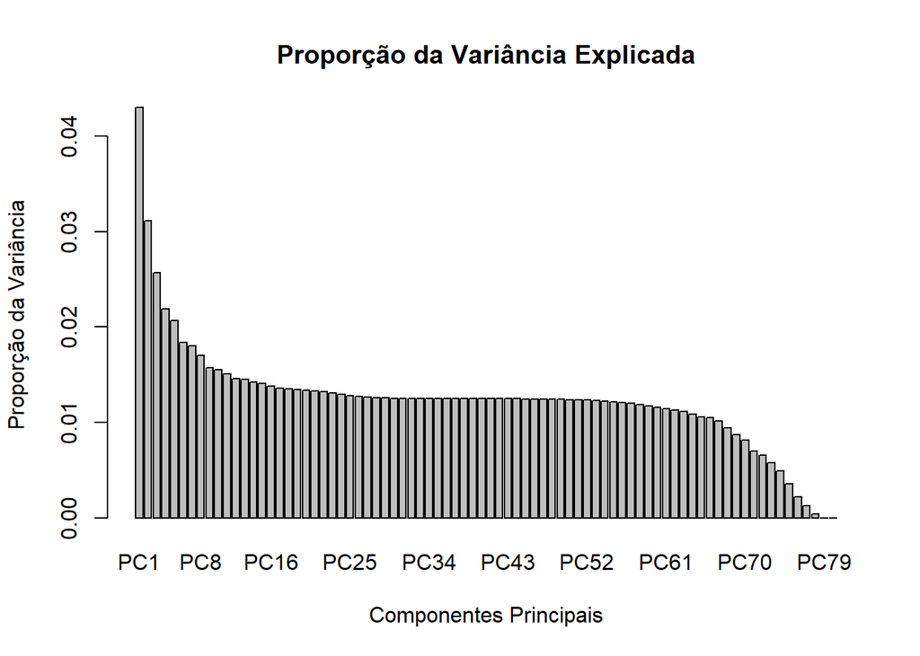

```r
# Gráfico da variância explicada
variance_explained <- summary(pca_result)$importance[2, ]
barplot(variance_explained, main = "Proporção da Variância Explicada",
        xlab = "Componentes Principais", ylab = "Proporção da Variância")
```

```r
# Cálculo do número de componentes que explicam 95% da variância
cumulative_variance <- cumsum(variance_explained)
num_components <- which(cumulative_variance >= 0.95)[1]

cat("Numero de componentes principais que explicam 95% da variancia:", num_components)
```

```
## Numero de componentes principais que explicam 95% da variancia: 68
```

```r
# Obter as componentes principais
pca_data <- as.data.frame(pca_result$x[, 1:num_components])

# Visualizar os dados transformados
head(pca_data)
```

|  | PC1 | PC2 | PC3 | PC4 | PC5 | PC6 | PC7 | PC8 | PC9 | PC10 | PC11 | PC12 | PC13 | PC14 | PC15 | PC16 | PC17 | PC18 | PC19 | PC20 | PC21 | PC22 | PC23 | PC24 | PC25 | PC26 | PC27 | PC28 | PC29 | … |
| --- | --- | --- | --- | --- | --- | --- | --- | --- | --- | --- | --- | --- | --- | --- | --- | --- | --- | --- | --- | --- | --- | --- | --- | --- | --- | --- | --- | --- | --- | --- |
| 10985 | 3.318954 | 2.77250698 | -2.04832032 | 0.10663767 | 0.796084158 | -1.8718603 | -3.0682985 | 0.1935011 | 0.5208678 | -1.8833194 | -0.5345813 | 0.90397951 | -0.749769757 | 0.25976132 | 0.1552774558 | -0.66188140 | -0.23416138 | -0.30554657 | -0.48466776 | -0.424392336 | -0.01424211 | 0.42525586 | -0.16390900 | 0.628762728 | 0.35998558 | 0.82987903 | -0.09528562 | -0.03708090 | -0.061711589 | … |
| 13876 | 1.698503 | -1.02492863 | -0.45907788 | -0.40241741 | 0.255213983 | 1.4018625 | -0.5294335 | 0.8029492 | 0.6376772 | -1.2779277 | -0.2019724 | 0.98715993 | -0.960587677 | -0.12144352 | -0.0002059415 | -0.60789390 | -0.59837119 | 0.19279759 | -0.22326151 | -0.158700974 | 0.07741712 | 0.31147774 | -0.52836098 | 0.178253983 | 0.13552633 | 0.17940544 | -0.29412657 | 0.05314705 | -0.069728818 | … |
| 21531 | -2.241859 | 0.07598404 | 0.01247386 | -1.19097435 | 0.042216843 | 0.1929800 | 0.8368687 | 0.2050584 | -1.4194250 | -0.2854555 | -0.2088286 | 0.12904818 | -0.009209015 | 0.01035558 | -0.4324687280 | -0.04285794 | -0.24128143 | 0.11068540 | -0.07815504 | 0.478667112 | -0.19039183 | -0.16000968 | 0.09483692 | 0.007076688 | 0.06639581 | -0.20176209 | -0.07567153 | -0.06295469 | 0.045870765 | … |
| 4953 | -2.667352 | 0.03256877 | -0.04744857 | 0.51909446 | -0.008451272 | 0.4365713 | -0.9104497 | -1.9424199 | 2.4401188 | 1.2780569 | 0.5843696 | -0.03716053 | 0.473775498 | 0.11123599 | 0.0108926712 | -0.66937141 | -0.01727034 | 0.89118229 | 0.12638185 | -0.012453973 | 0.48338527 | -0.23459400 | 0.07577108 | -0.776765302 | -0.12000785 | 0.16546592 | -0.45611396 | -0.29354625 | -0.062901109 | … |
| 6017 | -1.496748 | -0.47738334 | 1.18677980 | -0.02194607 | -0.597853594 | 0.9009233 | -0.8029693 | -0.1992145 | -0.8247769 | 0.7603982 | 0.6582941 | 0.04375539 | -1.872339095 | -0.37990013 | 0.3193238244 | 0.35483557 | 0.38586044 | 0.01660159 | 0.45165788 | -0.006261253 | 0.50029686 | 0.00411575 | -0.25864107 | 0.393403450 | 0.03920787 | -0.02567288 | 0.48417868 | 0.02995085 | -0.063286876 | … |
| 29355 | 1.245542 | -1.06152683 | -0.20975170 | -1.16506739 | 0.562511196 | 0.5570396 | -0.8959635 | -0.5697008 | -0.7422815 | 0.6555127 | 0.4847345 | 0.17826265 | -1.687910855 | -0.32664067 | 0.4899657722 | 0.28151458 | 0.49984293 | -0.35980692 | 0.07175060 | -0.604856553 | 0.29177290 | -0.01267192 | -0.34972185 | 0.293201609 | -0.18875513 | -0.17207068 | 0.38375415 | -0.13157335 | 0.009577616 | … |

A análise da proporção da variância é fundamental na PCA porque ajuda a decidir quantos componentes principais manter. O objetivo é reduzir a dimensionalidade dos dados enquanto retém a maior parte da informação relevante. A regra geral é manter componentes que, juntos, expliquem uma porcentagem significativa da variância (como 90% ou 95%). Neste caso, o número de componentes principais que explicam 95% da variância é 68. Portanto, podemos reduzir a dimensionalidade dos dados de 80 para 68 mantendo a maioria da informação relevante.